# Test your R install!

Not graded

# Introduction

This is an R install test document. We compile it in a way that the code will not be visible, you will just have the output. Imagine this is a report, and your boss is deeply uninterested in the code. But she very much wants to see the results!

The document should compile without errors, and produce a nice html.

# Load data from a non-default package

Here we loaded data (Galton 1886 parents/children height data) from package *UsingR*. You probably have to install that package. The dataset has 1078 rows.

# Use **dplyr** commands

Here we use dplyr to convert inches to centimeters: the fathers’ average height is 171.9 cm.

If it works, you have a functioning dplyr installation.

# Do some plotting

Finally, here is the plot of the data (`message=FALSE` avoids informative messages from code):

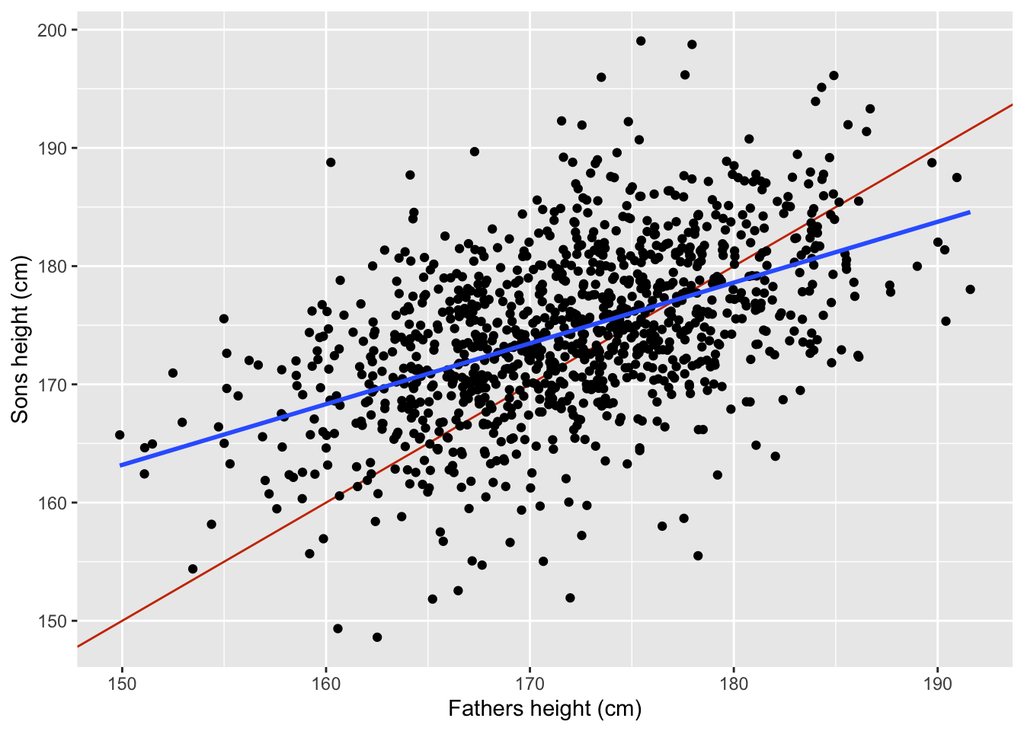

Height of parents and offsprings

The black dots depict parent-child pairs (although the data claims it is about fathers and sons, Galton was in fact also using mothers and daughters). The red line is one-to-one relationship, meaning that one cm taller parents have in average one cm taller children. As the blue regression line shows, this is not at all the case. Taller parents have taller children, but not as much above the mean as parents. This is what Galton (1886) called “regression to mediocrity” and we call “regression to mean”.